Based on the number of rows in the dataframe, I was able to calculate that there were: 340 shootings in 2018. In total, there were 373 people killed. The city that was most impacted by a shooting was Pompano Beach (Parkland). There were a total of 1720 gun violence victims in the year of 2018. The most deadly shooting in Pompano Beach (Parkland) happend on February 14, 2018.

```
##                 state.x state.freq total_shot
## 1               Alabama         14         67
## 2               Arizona          2          9
## 3              Arkansas          6         24
## 4            California         35        186
## 5              Colorado          8         36
## 6           Connecticut          2          8
## 7              Delaware          1          5
## 8  District of Columbia          6         25
## 9               Florida         30        180
## 10              Georgia          8         36
## 11             Illinois         35        171
## 12              Indiana          8         37
## 13               Kansas          2         12
## 14             Kentucky          4         32
```

[output cut: 23 more lines]

The shooting with the most people shot was in Pompano Beach (Parkland). There were a total of 34 of people shot here. This shooting happened on February 14, 2018. Out of the 34 people that were shot, 17 were injured and 17 were killed.

[interactive chart not shown]

This map is very useful because A) It provides a clear location on the mao for each mass shooting and B) It provides the name of each city where the shooting occured.

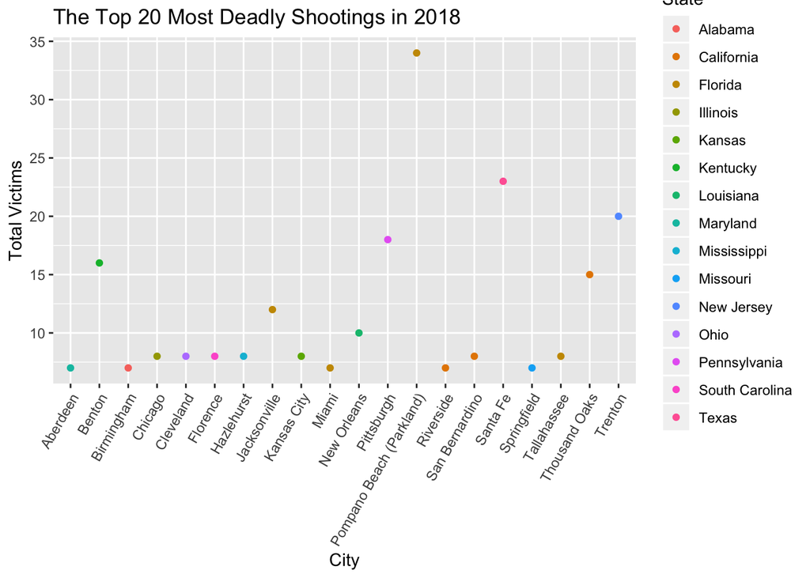

In Chapter 5 of Weapons of Math Destruction, Cathy O’Neil talks about how police use a crime prediction system, based on previous crime data, to find the areas with the highest likelihood of violent crimes. The link between non-violent crime and violent crime is strong enough that when the prediction system gathers data on non-violent crimes, it continues to predict that area for high violence, even if none occurs. The problem with this is that the system will encourage police to continuously arrest people for non-violent crimes in ‘high risk’ areas.